# Python for Noobs 🙂

## This notebook is gonna show you the syntax of Python, the easiest languange of ALL time 🐍

## If you want to run the Notebook,

## Downlad Python_for_Noobs2.ipynb from my GitHub Repository:

### *https://github.com/maxwellau/PyADSTutorials*

## Upload the .ipynb file into your Google Drive and open it with:

### *https://research.google.com/colaboratory/*

# TIPS 💁

### -To Comment a single line, use the **#** symbol, e.g. #ootd

### -To block comment, highlight the text and press CONTROL-SLASH 🎮 /

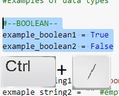

### -To run code block, hover your mouse on the code block and click on the play button on the left!

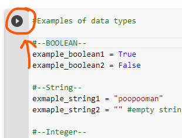

### -Finally, if there's anything you are not sure of, just Google it 🔍

# Variables and datatypes 🍠

## Boolean 🥦

## String 🧣

## Integer 🕤

## Float 🍽

## Lists/ Arrays 🥌

## Other Custom Data Types (Data Class/Struct) 🍸 (not covered)

```python
# Examples of data types
# Initialise this code block as the variables will be used
# in the next few codeblocks


#--BOOLEAN--
example_boolean1 = True
example_boolean2 = False

#--String--
exmaple_string1 = "poopooman"
exmaple_string2 = "" #empty string

#--Integer--
example_integer1 = 123
example_integer2 = 0

#--Float--
example_float1 = 123.0
example_float2 = 2345.23

#--Lists/Arrays--
list_1 = [1,2,3,4,5] #list of integers
list_2 = ["cat", "dog", "mouse", "hyena"] #list of strings
list_3 = [True, False, True] #list of booleans

#--Operators
print(example_boolean1 == example_boolean2) #equivalence
print(example_integer1 > example_integer2) #magnitude comparison
print(example_float1 <= example_float2) #equals to or less than
#Mathematical Operations are the same everywhere; If in doubt, google it :D
```

```
False
True
True
```

# Conditionals 🚒

### IF - ELSE 🔥

### IF - ELIF - ELSE 👿

### Unconditional Bypass 😵

# KEY 🔑

### Conditional statements, and code blocks in general **require *PROPER* indentations and a colon ":"**

## In Structured text, an *IF* statement is written with END statements:

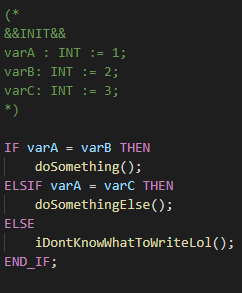

## In C-Sharp, an *IF* statement is written with curly braces {} to denote codeblocks:

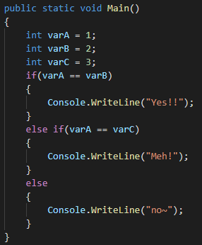

# 🐍 In python, we use indentation blocks (usually with the 📑tab button) to denote seperate codedblocks. Refer to the codeblocks below!

# 📓 Take note of how the code that depends on the conditional is on the **SAME INDENT!**

# ❔ Excercise for reader : Play around with the declared Variables in the previous cell, what do you notice when you compare Booleans and Strings? 🤔

```python
#Examples of conditional statements using previously declared data


#--Classic If-Else--
print("===================\nClassic If-Else Statement")
if example_integer1 == example_integer2:
  print("Its the same!!~")
else: print("It ain't the same") #you can do this too!


#--If-Elif-Else--
print("===================\nIf-Elif-Else Statement")
if example_integer1 == example_integer2:
  print("Its the same!!~")
elif type(example_integer1) == type(example_integer2):
  print("BUT they have the same data type!~")
else:
  print("It ain't the same")


#--Unconditional Bypass--
print("===================\nUnconditional Bypass")
if True:
  print("No matter what, I will always be TRUE!")
```

```
===================
Classic If-Else Statement
It ain't the same
===================
If-Elif-Else Statement
BUT they have the same data type!~
===================
Unconditional Bypass
No matter what, I will always be TRUE!
```

# Loops ⭕⭕

### WHILE LOOP ⚡

### FOR LOOP ⏯

### INFINITE LOOP 😵

# KEY 🔑

### Loops, similar to IF statements, **require *PROPER* indentations and a colon ":"**

### In a FOR loop, the reference "i" refers to the OBJECT in the list, can be a string, integer, boolean or struct/dataclass, similar to "foreach" in Csharp

```python
#Examples of loop statements using previously declared lists


#--While loop to iterate through list--
print("===================\nIteration with While Loop\n")
i = 0 #initialising integer
while i < len(list_1): #whereby len(list_1) returns the number of elements in list_1
  print(list_1[i])
  i+=1


#--For loop to iterate through list--
print("===================\nIteration with For Loop\n")
for i in list_2:
  print(i)


#--Infinite Loop(Commented out to prevent overloading)--
print("===================\nInfinite Loop\n")
# while True:
#   print("running!")
```

```
===================
Iteration with While Loop

1
2
3
4
5
===================
Iteration with For Loop

cat
dog
mouse
hyena
===================
Infinite Loop
```

# Functions ⛲

### Parameterless Methods ⚡

### Parameterized Methods ⛽

# KEY 🔑

### Functions, similar to IF statements, **require *PROPER* indentations and a colon ":"**

### We do not need to declare the returned data type as python inteprets it for us!

### This is in ✨**contrast**✨ to Structured Text or Csharp, here's a simple **addition function example!**

# In Csharp 🦈

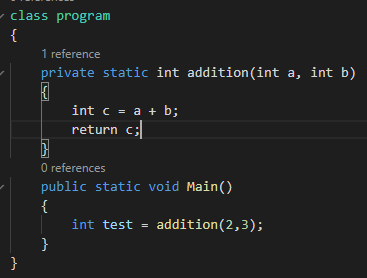

# In Structured Text 🚧

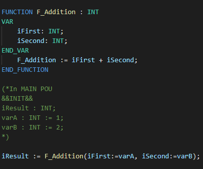

```python
#Examples of Methods in Python

#--Parameterless Method--
print("The no_params method takes in NO parameters and just prints out 'I love Chicken Rice!'")
def no_params():
  print('I love Chicken Rice!')


#--Parameterized Functions--
print("The with_params method takes ONE parameter and prints out what you like to eat!")
def with_params(food):
  print(f'I love eating {food}')


#--Parameterized Functions WITH Return--
print("The addition method takes 2 parameters and returns the sum of those 2")
def addition(a,b):
  c = a + b
  return c
```

```
The no_params method takes in NO parameters and just prints out 'I love Chicken Rice!'
The with_params method takes ONE parameter and prints out what you like to eat!
The addition method takes 2 parameters and returns the sum of those 2
```

# ✨✨✨ TRY IT OUT ✨✨✨

```python
#How to RUN a method in Python

#--Parameterless Method--
print("This parameterless method takes in NO parameters and just prints out 'I love Chicken Rice!'")
no_params()

#--Parameterized Functions--
print("\nThis parameterized method takes ONE parameter and prints out what you like to eat!")
with_params(food = "Cookies")

#--Parameterized Functions WITH Return--
print("\nThis parameterized method takes 2 parameters and returns the sum of those 2")
result = addition(1,2); print(result) # ';' indicates end of line
```

```
This parameterless method takes in NO parameters and just prints out 'I love Chicken Rice!'
I love Chicken Rice!

This parameterized method takes ONE parameter and prints out what you like to eat!
I love eating Cookies

This parameterized method takes 2 parameters and returns the sum of those 2
3
```

# ❓ Excercises for Reader:

# Question 1:

## ❓Given an Array of integers, **[3, 5, 2, 723, 4, 7, 8, 16]**, make 2 new arrays that contains even and odd integers respectively. Finally, print those out!

## It is given that you can make 2 empty arrays, and can add elements using the function:

# `ListName.append(newItem)`

## For Example,

```
givenArray = [1,2,3]
givenArray.append(4)
print(givenArray)
outputs --> [1,2,3,4]
```

## You are also given that the **modulo '%' symbol returns the remainder** after division:

## `4 % 2 = 0`

```python
givenArray = [3, 5, 2, 723, 4, 7, 8, 16]
oddArray = []
evenArray = []
# s
# o
# l
# u
# t
# i
# o
# n
print(f"oddArray is {oddArray}")
print(f"evenArray is {evenArray}")
```

# Question 2:

## ❓Create a Function/Method *(same thing...)* that takes in 4 parameters:

1. favourite food
2. favourite drink
3. favourite pastime
4. time you sleep

## Then return the string and print it out!

## You are given that you can **concatenate strings with the + operator:**

### `'string_1' + 'string_2' = "string_1string_2"`

#### Example Output: **"I love to eat Icon幼面，I like drinking Bubble Tea, I like to Dance, I sleep at 3"**

```python
def alibaba(food, drink, pasttime, sleeptime):
  #solution here
  return #something
solution = alibaba(#enter parameters here)
print(solution)
```

# Question 3:

## ❓ You are given a 2D Matrix:

```
[[0,None,2,69],
[3,4,5,69],
[6,7,8,69],
[9,10,11,69],
[12,13,14,None]]
```

# **Transpose the matrix and print the solution, replace *None* values with 0.**

## *i.e. rows become columns, columns become rows*

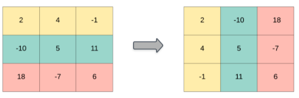

## You are given that you can create new variables from strings with:

# `vars()["newVariable"] = newVariable`

## And can delete variables by calling:

# `del newVariable`

## You can check if the variable exists by doing a try and except:

```
  try:
    someInteger += 1 #if variable exists, add 1
  except: #if variable doesnt exist
    vars()["someInteger"] = 0 #create new variable called someInteger
```

```python
matrix = [[0,None,2,69],
          [3,4,5,69],
          [6,7,8,69],
          [9,10,11,69],
          [12,13,14,None]]

def transpose_matrix(matrixInput):
  # S
  # O
  # L
  # U
  # T
  # I
  # O
  # N
  return #something

transposedMatrx = transpose_matrix(matrix)

print(transposedMatrx)
```

# Heres a Cat Picture 'cuz idk what to put

[figure not shown]

# 🥵🥵🥵🥵🥵🥵 **SOLUTION!!!!!!!!** 🥵🥵🥵🥵🥵🥵

```python
#Solution for Question 1

givenArray = [3, 5, 2, 723, 4, 7, 8, 16]
oddArray = []
evenArray = []
for i in givenArray:
  if i%2 == 0:
    evenArray.append(i)
  else:
    oddArray.append(i)
print(f"oddArray is {oddArray}")
print(f"evenArray is {evenArray}")
```

```
oddArray is [3, 5, 723, 7]
evenArray is [2, 4, 8, 16]
```

```python
#Solution for Question 2

def alibaba(food, drink, pasttime, sleeptime):
  taobao = f"I love to eat {food}, I like drinking {drink}, I like to {pasttime}, I sleep at {sleeptime}"
  return taobao
answer = alibaba(food = "Icon幼面", drink = "Bubble Tea", pasttime = "Dance", sleeptime = 3)
print(answer)
```

```
I love to eat Icon幼面, I like drinking Bubble Tea, I like to Dance, I sleep at 3
```

```python
#Solution for Question 3, there are 2 solutions
#P.S. If you need more explaination just ask me :D

matrix = [[0,None,2,69],
          [3,4,5,69],
          [6,7,8,69],
          [9,10,11,69],
          [12,13,14,None]]

#row first search
def transpose_matrix_1(matrixInput):
  for i in range(len(matrixInput)):
    for j in range(len(matrixInput[i])):
        try:
          if matrixInput[i][j] != None:
            vars()[f"row{j}"].append(matrixInput[i][j])
          else:
            vars()[f"row{j}"].append(0)
        except:
          if matrixInput[i][j] != None:
            vars()[f"row{j}"] = [matrixInput[i][j]]
          else:
            vars()[f"row{j}"] = [0]
  transposed = []
  for i in range(len(matrixInput[0])):
    transposed.append(vars()[f"row{i}"])
    del vars()[f"row{i}"]
  return transposed


#column first search (reccomended)
def transpose_matrix_2(matrixInput):
  matrix_output = []
  for i in range(len(matrixInput[0])):
    row = []
    for j in range(len(matrixInput)):
      if matrixInput[j][i] != None:
        row.append(matrixInput[j][i])
      else:
        row.append(0)
    matrix_output.append(row)
  return matrix_output

solution_1 = transpose_matrix_1(matrix)
solution_2 = transpose_matrix_2(matrix)
print("Using first solution : ",solution_1)
print("Using first solution : ",solution_2)
print("Are they the same? ",solution_1 == solution_2)
```

```
Using first solution :  [[0, 3, 6, 9, 12], [0, 4, 7, 10, 13], [2, 5, 8, 11, 14], [69, 69, 69, 69, 0]]
Using first solution :  [[0, 3, 6, 9, 12], [0, 4, 7, 10, 13], [2, 5, 8, 11, 14], [69, 69, 69, 69, 0]]
Are they the same?  True
```

# THE END

# ✌ Thanks for reading! ✌

# This is only the basics, python is easy to pick up if you ask **Uncle Google** along the way. Ctrl-C Ctrl-V is your best friend 😀

# 💅 Ask me anything if you've got questions 💅